# HMM.Hidden Markov Model

Doynikov A.

October 27, 2022

# Марковские модели

Марковская модель - важное свойство многих моделей случайных процессов. В Марковской модели порядка $m$ совместное распределение $p(y_{t_{1:T}})=p(y_1,...,y_T)$ случайного процесса с дискретным временем $y_t\mspace{25mu}t=1,2...$ факторизуется
$$p(y_{t_{1:T}})=\prod_{t=1}^Tp(y_t|y_{t-m:t-1})$$
которое отражает тот факт, что только последние $m$ наблюдений $t_{t-m:t-1}$ непосредственно влияют на $y_t$ а переходные вероятности $p(y_t|y_{t-m:t-1}$ независимы.

## Оценка матрицы переходных вероятностей в дискретных Марковских моделях

В однородных первого порядка Марковских моделях с дискретным скалярными наблюдениями $y_t\in {1,...,S}$ переход из момента времени $t-1$ в $t$ может быть параметризован, используя матрицу $\theta$ переходных вероятностей за единицу времени.
$$\theta_{ji}=p({y_t=j|y_{t-1}=i}), i,j \in
[1,...,S].$$
Если наблюдения за процессом приняли значения $y_1,...,y_T$, то оценка максимального правдоподобия будет матрица
$$\theta^{ML}=\max_{\theta}ln(p(y_{1:T}))=
\max_{\theta}\sum_{t}ln(p(y_t|y_{t-1})).$$

## Стационарное распределение цепи Маркова

Пусть $y_t$ — однородная цепь Маркова с дискретным временем, счётным пространством состояний $1,2,\ldots$, и матрицей переходных вероятностей $\Theta=(\theta_{ij}),i,j=1,2,\ldots$. Тогда дискретное распределение $q =(q_{1},q_{2},\ldots)$ называется стациона́рным (инвариа́нтным), если
$$q\Theta=q$$

## Классификация состояний цепи Маркова

Состояние $s_j$ дискретной цепи Маркова называется поглощающим, если его невозможно покинуть, что означает $\theta_{j,j}=1$. Поглощающая цепь Маркова - это цепь, которая содержит, по крайней мере, одно поглощающее состояние, которое может быть достигнуто, не обязательно в один шаг. Непоглощающие состояния поглощающей цепи Маркова определяются как переходные состояния. Кроме того, состояния, которые процесс может посещать более одного раза, называются рекуррентными состояниями.

Цепь Маркова называется *неприводимой*, если любое состояние $s_j$ может быть достигнуто из любого другого состояния $s_i$ за конечное число переходов. В этом случае все состояния цепи называются сообщающимися,

Дискретный Марковский процесс называется *эргодическим*, если существует число $N$, что можно достичь любого состояния не более чем за $N$ шагов.

## Пример. Модель изменения погоды

В качестве примера Марковского процесса с дискретным временем и дискретным множеством состояний рассмотрим процесс изменения погоды. Состояний у процесса будет три. Нам понадобится библиотека *markovchain*.Возможно первый раз ее придется устанавливать через *devtools*.

```r
#devtools::install_github("spedygiorgio/markovchain")
library("markovchain")
```

Создадим объект с тремя состояниями и матрицу переходных вероятностей изменения погоды за один день

```r
weatherStates <- c("rainy", "nice", "sunny")
weatherMatrix <- matrix(data = c(0.50, 0.25, 0.25,
                                 0.5, 0.0, 0.5, 0.25, 0.25, 0.5), byrow = TRUE,
                        nrow = 3,dimnames = list(weatherStates, weatherStates))
weatherMatrix
```

```
##       rainy nice sunny
## rainy  0.50 0.25  0.25
## nice   0.50 0.00  0.50
## sunny  0.25 0.25  0.50
```

```r
mcWeather <- new("markovchain", states = weatherStates,
                 byrow = TRUE, transitionMatrix = weatherMatrix,
                 name = "Weather")
```

Специальный метод позволяет рисовать объекты типа *markovchain*:

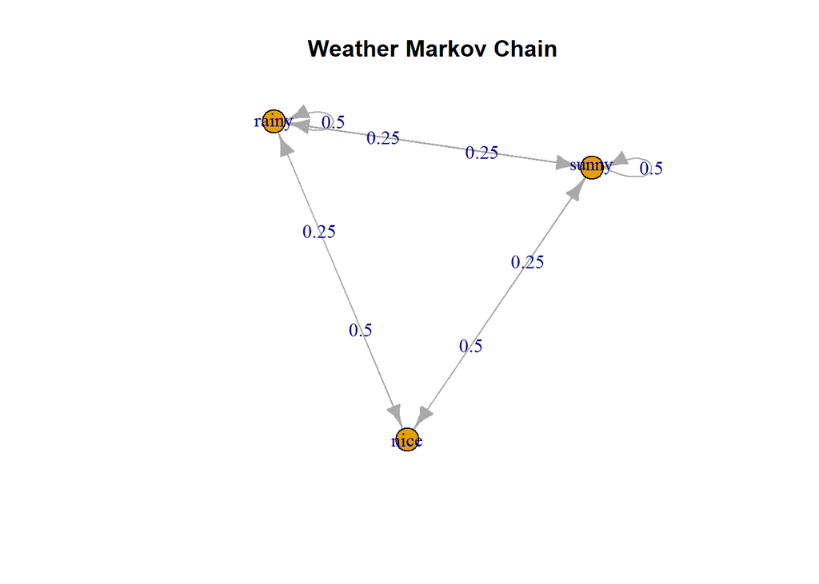

```r
plot(mcWeather, main="Weather Markov Chain")
```

Посмотрим некоторые алгебраические операции над моделью *markovchain*.

Зададим начальное распределение вероятностей погоды, тогда распределение вероятностей погоды через 2 дня будет

```r
initialState <- c(0, 1, 0)
after2Days <- initialState * (mcWeather * mcWeather)
after2Days
```

```
##      rainy nice sunny
## [1,] 0.375 0.25 0.375
```

Cоздадим еще один Марковский процесс с четырьмя состояниями.

```r
mathematicaMatr <- matrix(c(1/2, 1/2, 0, 0, 1/2, 1/2,
0, 0, 1/4, 1/4, 1/4, 1/4, 0, 0, 0, 1),byrow=TRUE, nrow=4)
mathematicaMc<-as(mathematicaMatr, "markovchain")
```

Проверим является ли он Марковским

```r
is(mathematicaMc,"markovchain")
```

```
## [1] TRUE
```

Нарисуем состояния процесса

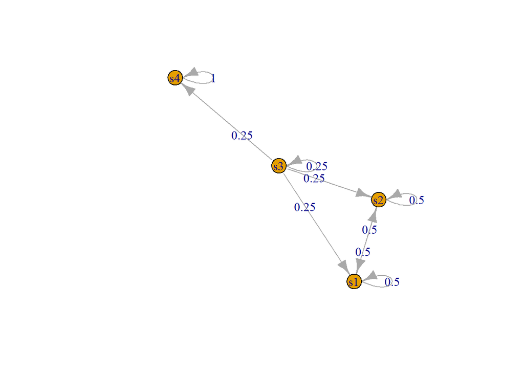

```r
plot(mathematicaMc)
```

Классификация состояний процесса

```r
summary(mathematicaMc)
```

```
## Unnamed Markov chain  Markov chain that is composed by:
## Closed classes:
## s1 s2
## s4
## Recurrent classes:
## {s1,s2},{s4}
## Transient classes:
## {s3}
## The Markov chain is not irreducible
## The absorbing states are: s4
```

### Стационарное распределение

У неприводимой цепи Маркова можно найти стационарное распределение.

```r
## when the TM is irreducibile
steadyStates(mcWeather)
```

```
##      rainy nice sunny
## [1,]   0.4  0.2   0.4
```

### Моделирование Марковской модели погоды

Пусть начальное состояние погоды *t0 = “sunny”*. Моделируем дискретный Марковский процесс с начальным состоянием *t0*.

```r
weathersOfDays <- rmarkovchain(n = 30, object = mcWeather, t0 = "sunny")
weathersOfDays
```

```
##  [1] "sunny" "rainy" "rainy" "nice"  "rainy" "rainy" "sunny" "nice"  "sunny"
## [10] "nice"  "rainy" "nice"  "rainy" "sunny" "sunny" "sunny" "sunny" "nice"
## [19] "sunny" "nice"  "rainy" "nice"  "rainy" "nice"  "sunny" "sunny" "rainy"
## [28] "rainy" "nice"  "sunny"
```

### Оценивание Марковской модели погоды

В библиотеке *markovchain* есть реальный ряд погоды

```r
data(rain)
rain$rain[1:10]
```

```
##  [1] "6+"  "1-5" "1-5" "1-5" "1-5" "1-5" "1-5" "6+"  "6+"  "6+"
```

Оценим эмпирическую матрицу числа изменений погоды за один день.

```r
mc <- createSequenceMatrix(stringchar = rain$rain)
mc
```

```
##       0 1-5  6+
## 0   362 126  60
## 1-5 136  90  68
## 6+   50  79 124
```

Оценивание параметров Марковской цепи методом максимального правдоподобия.

```r
alofiMcFitMle <- markovchainFit(data = rain$rain, method = "mle", name = "Alofi")
alofiMcFitMle$estimate
```

```
## Alofi
##  A  3 - dimensional discrete Markov Chain defined by the following states:
##  0, 1-5, 6+
##  The transition matrix  (by rows)  is defined as follows:
##             0       1-5        6+
## 0   0.6605839 0.2299270 0.1094891
## 1-5 0.4625850 0.3061224 0.2312925
## 6+  0.1976285 0.3122530 0.4901186
```

```r
alofiMcFitMle$standardError
```

```
##              0        1-5         6+
## 0   0.03471952 0.02048353 0.01413498
## 1-5 0.03966634 0.03226814 0.02804834
## 6+  0.02794888 0.03513120 0.04401395
```

```r
alofiMcFitMle$logLikelihood
```

```
## [1] -1040.419
```

## Модель авторегрессии

Важным примером Марковской модели порядка $m$ являются уже изветные нам модели авторегрессии соответствующего порядка $m$.
$$y_t=a_1y_{t-1}+a_2y_{t-2}+...+a_my_{t-m}+\epsilon_t$$
Здесь $a_{1:m}$ - коэффициенты авторегрессии и $\epsilon_t$ - независимый белый шум обычно предполагаемый как нормально распределенный с нулевым ожиданием и дисперсией $\sigma^2$. Так называемая производящая форма для AR модели задается соотношением
$$p(y_{1:T}|y_{1:m})=\prod_{t=m+1}^Tp(y_t|y_{t-m:t-1})$$
$$p(y_t|y_{t-m:t-1})=\mathcal
N(y_t|\sum_{i=1}^ma_iy_{t-i},\sigma^2)$$
Для наблюдений $y_{1:T}$ оценка максимально правдоподобия для параметров $\alpha_i$ и $\sigma^2$ получается максимизацией относительно $a$ и $\sigma^2$ логарифма функции правдоподобия
$$ln(p(y_{1:T}|y_{1:m}))=
-\frac{1}{2\sigma^2}\sum_{t=m+1}^T(y_t-\sum_{i=1}^{m}a_iy_{t-i})^2-\frac{T-m}{2}ln(2\pi\sigma^2)$$

Другой изветсный нам уже метод оценки параметров называется Левинсона-Дурбина.

Оптимальный набор $a_{1:m}$ задаются решением системы линейных уравнений Юла-Уокера
$$\sum_ia_i\sum_{t=m+1}^Ty_{t-i}y_{t-j}=\sum_{t=m+1}^Ty_ty_{t-j},
\forall j,$$
которая решается методом Левинсона-Дурбина. Оптимальная оценка дисперсии задается
$$\sigma^2=\frac{1}{T-m}\sum_{t=m+1}^T(y_t-\sum_{i=1}^ma_iy_{t-i})^2$$

Данные выражения справедливы и если $y_t$ многомерный процесс только при этом $a_i$ - матрицы и $\epsilon_t$ - вектор. Обобщение называется векторной авторегрессией.

# Скрытая марковская модель (HММ)

Скрытая марковская модель (СММ) англ. Hidden Markov Model (HMM) — статистическая модель, имитирующая работу процесса, похожего на марковский процесс с неизвестными параметрами, и задачей ставится разгадывание неизвестных параметров на основе наблюдаемых. Полученные параметры могут быть использованы в дальнейшем анализе, например, для распознавания образов.

В обычной марковской модели состояние видимо наблюдателю, поэтому вероятности переходов — единственный параметр. В скрытой марковской модели мы можем следить лишь за переменными, на которые оказывает влияние данное состояние. Каждое состояние имеет вероятностное распределение среди всех возможных выходных значений. Поэтому последовательность символов, сгенерированная СММ, даёт информацию о последовательности состояний.

Значение скрытой переменной $x_t$ (в момент времени $t$) зависит только от значения скрытой переменной $x_{t-1}$ (в момент $t-1$. Это называется свойством Маркова. Хотя в то же время значение наблюдаемой переменной $y_t$ зависит только от значения скрытой переменной $x_t$ (обе в момент времени $t$).

На диаграмме, представленной ниже, отображена взаимосвязь скрытой и наблюдаемой пременной.

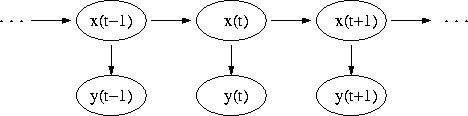

Классическим примером анализа скрытых марковских моделей является анализ функционирования рынка. Например, ежедневные данные о доходах на рынках акций часто имеют период спокойной более низкой волатильности, даже в течение ряда лет, с другой стороны встречаются периоды высокой волатильности в моменты «паники» или «коррекции».

## Моделирование динамики рынка ценных бумаг

В этом разделе смоделированные данные доходностей будут генерироваться из отдельных распределений Гаусса, каждый из которых представляет собой *бычье* или *медвежье*» состояние рынка. Анализ исторических данных торгов показывает, что *бычий рынок* характеризуется в среднем положительной доходностью и низкой волатильностью (дисперсией), в то время как в период *медвежьего рынка* доходность выбирается из распределения Гаусса с небольшим отрицательным средним, но более высокой волатильностью (дисперсией).

В R есть несколько пакетов для работы со скрытыми Марковскими моделями: *HMM* (Himmelmann, 2010), *HiddenMarkov* (Harte, 2012), и *depmixS4*. Здесь мы остановимся на пакете *depmixS4*. Возможно, что установка пакета в первый раз требуют его установки через *devtools*.

```r
#devtools::libraryinstall_github("cran/depmixS4")
library(depmixS4)
library(quantmod)
set.seed(1)
```

В нашем примере будет $k=5$ режимов рынка *бычьего* или *медвежьего* и длительность каждого периода будет случайная величина $N_k \in [50,150]$ дней. Доходности *бычьего рынка* будут распределены как $\mathcal N(0.1,0.1)$, а доходности при *медвежьем рынке* будем предполагать, что распределены как $\mathcal N(−0.05,0.2)$.

```r
# Create the parameters for the bull and
# bear market returns distributions
Nk_lower <- 50
Nk_upper <- 150
bull_mean <- 0.1
bull_var <- 0.1
bear_mean <- -0.05
bear_var <- 0.2
```

Значения $N_k$ возьмем случайными, равномерно распределенными на отрезке $[50,150]$

```r
# Create the list of durations (in days) for each regime
(days <- replicate(5, sample(Nk_lower:Nk_upper, 1)))
```

```
## [1] 117  88  50  83 136
```

Cмоделируем доходности в каждом из периодов

```r
# Create the various bull and bear markets returns
market_bull_1 <- rnorm( days[1], bull_mean, bull_var )
market_bear_2 <- rnorm( days[2], bear_mean, bear_var )
market_bull_3 <- rnorm( days[3], bull_mean, bull_var )
market_bear_4 <- rnorm( days[4], bear_mean, bear_var )
market_bull_5 <- rnorm( days[5], bull_mean, bull_var )
```

Получим ряд отображающий конкретный номер режима 1 -бычий или 2 - медвежий и сопоставим ему ряд соответствующих доходностей

```r
# Create the list of true regime states and full returns list
true_regimes <- c( rep(1,days[1]), rep(2,days[2]), rep(1,days[3]), rep(2,days[4]), rep(1,days[5]))
returns <- c( market_bull_1, market_bear_2, market_bull_3, market_bear_4, market_bull_5)
```

Построим график смоделированного ряда доходностей

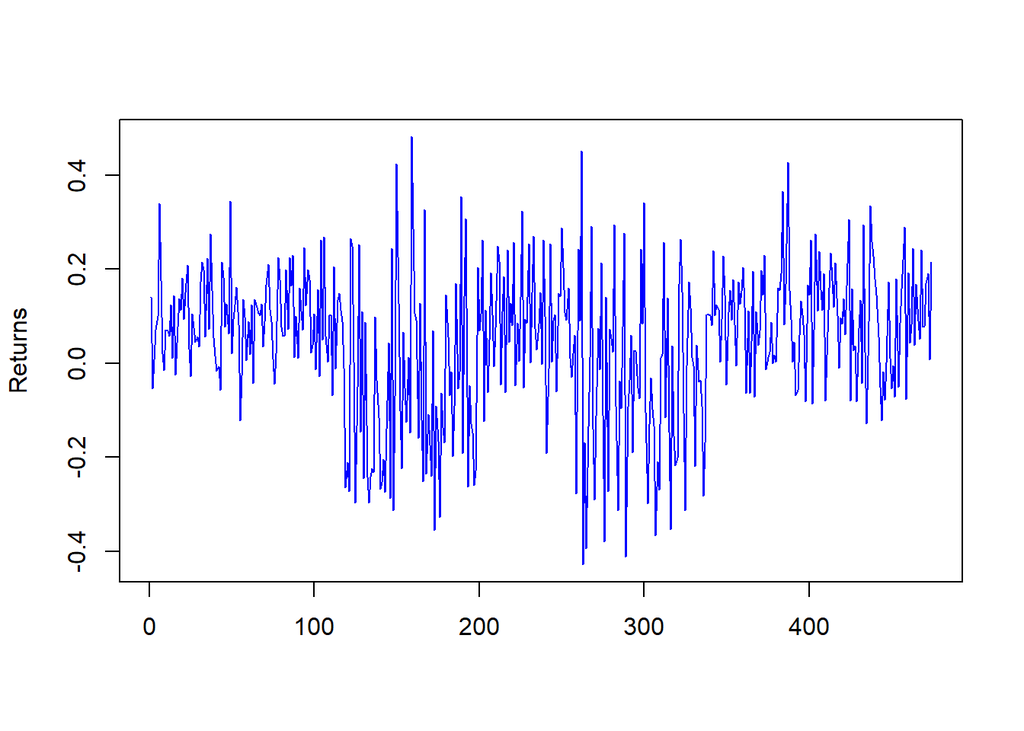

```r
plot(returns, type="l", col = 'blue' ,xlab='', ylab="Returns")
```

Мы теперь готовы оценить модель. Семейство распределений объявим Гауссовским, число скрытых состояний 2.

```r
# Create and fit the Hidden Markov Model
hmm <- depmix(returns ~ 1, family = gaussian(), nstates = 2, data=data.frame(returns=returns))
hmmfit <- fit(hmm, verbose = FALSE)
```

```
## converged at iteration 24 with logLik: 289.6389
```

```r
# Output both the true regimes and the
# posterior probabilities of the regimes
post_probs <- posterior(hmmfit)
```

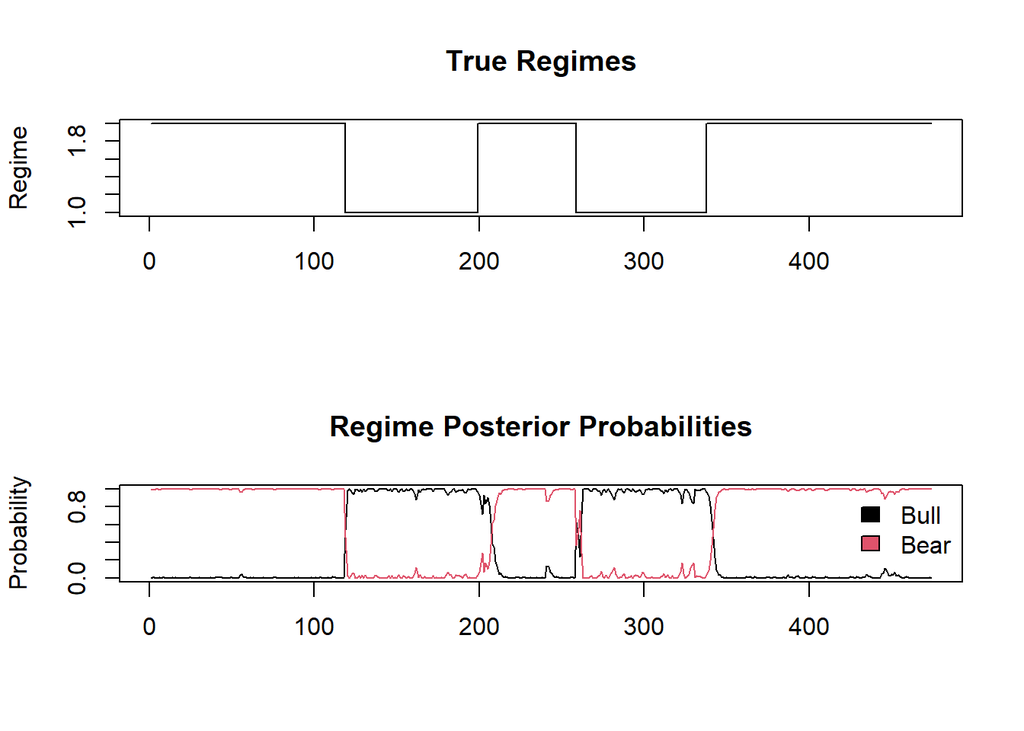

```r
layout(1:2)
plot(post_probs$state, type='s', main='True Regimes', xlab='', ylab='Regime')
matplot(post_probs[,-1], type='l', lty = 1,main='Regime Posterior Probabilities', ylab='Probability')
legend(x='topright', c('Bull','Bear'), fill=1:2, bty='n')
```

## Курс RUB/USD

В этом разделе будут выполнены две отдельные задачи оценивания. Первая оценка будет включать подгонку HMM с двумя режимами состояния для исторических доходностей дневных данных RUB/USD, а второе оценнивание будет использовать три состояния. Результаты двух моделей будут сравнены между собой.

```r
library(xts)
rubusd <- read.table('./RUB_USD.csv',sep = ',', header = TRUE )
head(rubusd)
```

```
##       Date RUB.USD
## 1 08/01/13   33.08
## 2 08/02/13   32.83
## 3 08/03/13   32.83
## 4 08/05/13   32.88
## 5 08/06/13   32.97
## 6 08/07/13   32.96
```

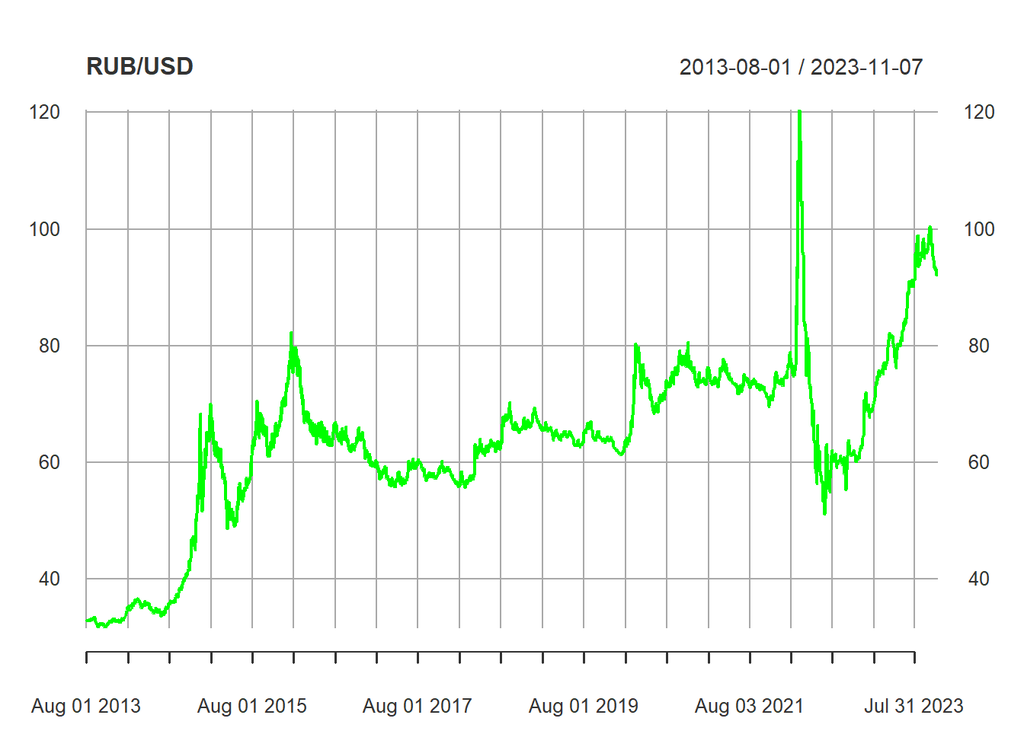

```r
Dates <-as.Date(rubusd[,1],"%m/%d/%y")
histData <- rubusd[,2]
sample.xts <- as.xts(histData, order.by = Dates)
plot(sample.xts,type = 'l',main = 'RUB/USD',col= 'green' )
```

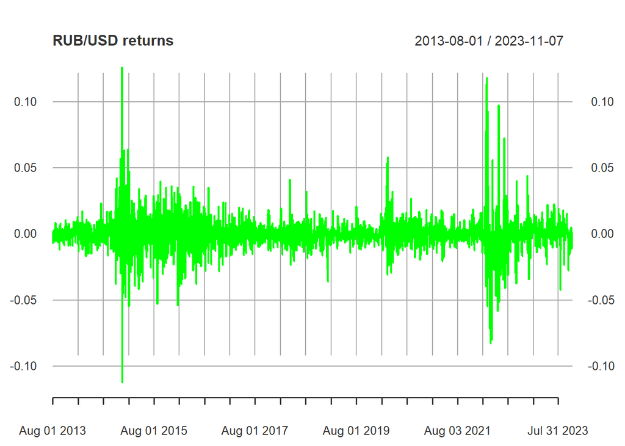

```r
rub.returns = diff( log(  sample.xts )  )

plot(rub.returns,type = 'l',main = 'RUB/USD returns',col = 'green')
```

Оценим параметры скрытой цепи Маркова с двумя состояниями.

```r
hmm <- depmix(rub.returns ~ 1, family = gaussian(), nstates = 2, data=data.frame(rub.returns=rub.returns))
hmmfit <- fit(hmm, verbose = FALSE)
```

```
## converged at iteration 33 with logLik: 10153.1
```

```r
post_probs <- posterior(hmmfit)
```

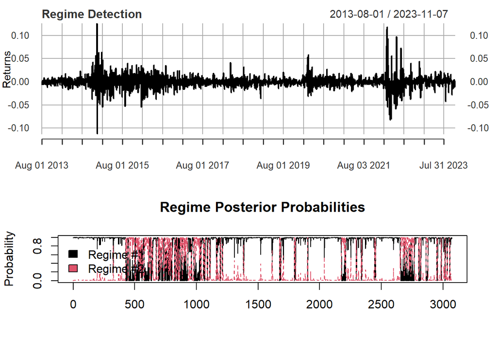

```r
# Plot the returns stream and the posterior
# probabilities of the separate regimes
layout(1:2)
plot(rub.returns, type='l', main='Regime Detection', xlab='', ylab='Returns')
matplot(post_probs[,-1], type='l', main='Regime Posterior Probabilities', ylab='Probability')
legend(x='bottomleft', c('Regime #1','Regime #2'), fill=1:2, bty='n')
```

Наблюдая за графиком апостериорных распределений режимов, отметим, что второй (красный) режим и более волатильный стал преобладать с второй половины 2014 годаи продолжался почти весь 2015-й. В этот время сильно снизились цены нефть с 100 ДО 30-40 долларов, периодически рубль нервировали экономические санкции США и Европейских стран за Украину и Крым. в 2017-2018 году цены на нефть пдросли до 70 долларов за баррель и рубль нервировали только санкции США за “отравление” Скрипалей в Великобритании в апреле и августа 2018. Затем видим режим высокой волатильности в феврале - марте 2022 года в связи с началом СВО.

Повторим процесс оценивания для трех режимов цепи Маркова

```r
hmm <- depmix(rub.returns ~ 1, family = gaussian(), nstates = 3, data=data.frame(rub.returns=rub.returns))
hmmfit <- fit(hmm, verbose = FALSE)
```

```
## converged at iteration 100 with logLik: 10270.85
```

```r
post_probs <- posterior(hmmfit)
```

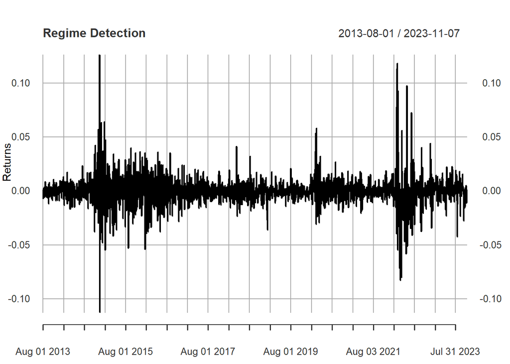

```r
# Plot the returns stream and the posterior
# probabilities of the separate regimes
plot(rub.returns, type='l', main='Regime Detection', xlab='', ylab='Returns')
```

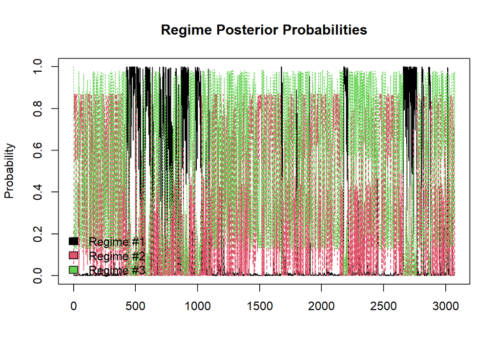

```r
matplot(post_probs[,-1], type='l', main='Regime Posterior Probabilities', ylab='Probability')
legend(x='bottomleft', c('Regime #1','Regime #2', 'Regime #3'), fill=1:3, bty='n')
```

```r
ruble <- c("low", "midle", "high")
hmm <- depmix(rub.returns ~ 1, family = gaussian(), nstates = 3, data=data.frame(rub.returns=rub.returns))
#mcRuble <- new("markovchain", states = rubleStates,
#                 byrow = TRUE, transitionMatrix = weatherMatrix,
#                name = "Ruble")
```

Можно выделить доходности для каждого из 3 состояний

```r
tail(hmmfit@posterior)
```

```
##      state          S1          S2        S3
## 3068     2 0.005016558 0.521885004 0.4730984
## 3069     2 0.002315463 0.725199041 0.2724855
## 3070     3 0.005325397 0.488243569 0.5064310
## 3071     3 0.005269083 0.442432559 0.5522984
## 3072     3 0.018140455 0.003742559 0.9781170
## 3073     3 0.004851486 0.422597985 0.5725505
```

```r
ind1 <- which(hmmfit@posterior$state==1)
state1_rates <-rub.returns[ind1]
head(state1_rates)
```

```
##                     [,1]
## 2014-10-29  0.0176148609
## 2014-10-30 -0.0377168178
## 2014-10-31  0.0340889189
## 2014-11-01 -0.0002068433
## 2014-11-03  0.0130239941
## 2014-11-04 -0.0004474781
```

```r
ind2 <- which(hmmfit@posterior$state==2)
state2_rates <-rub.returns[ind2]
head(state2_rates)
```

```
##                    [,1]
## 2013-08-03  0.000000000
## 2013-08-05  0.001521839
## 2013-08-06  0.002733487
## 2013-08-07 -0.000303352
## 2013-08-08 -0.003951974
## 2013-08-09  0.001825929
```

```r
ind3 <- which(hmmfit@posterior$state==3)
state3_rates <-rub.returns[ind3]
head(state3_rates)
```

```
##                    [,1]
## 2013-08-01           NA
## 2013-08-02 -0.007586139
## 2013-08-21  0.008466939
## 2013-08-22 -0.004829469
## 2013-09-09 -0.004511964
## 2013-09-10 -0.006351148
```

Вспомним лекцию 2 весеннего семестра и вычислим однодневный VaR(Value at Risk) уровня 95% для каждого из состояний

```r
library(PerformanceAnalytics)
```

```r
(VAR1 <- VaR(-state1_rates, p=.95, method="historical"))
```

```
##            [,1]
## VaR -0.03639986
```

```r
(VAR2 <- VaR(-state2_rates, p=.95, method="historical"))
```

```
##             [,1]
## VaR -0.004473394
```

```r
(VAR3 <- VaR(-state3_rates, p=.95, method="historical"))
```

```
##            [,1]
## VaR -0.01505165
```

```r
VAR <- c(VAR1,VAR2,VAR3)
```

Оценим матрицу переходных состояний

```r
hmm <- markovchainFit(data = hmmfit@posterior$state, method = "mle", name = "Alofi")
trmatr <- hmm$estimate@transitionMatrix
```

Подготовим матрицу переходных вероятностей

```r
States <- c("1", "2", "3")
colnames(trmatr) <- States
rownames(trmatr) <- States

trmatr <- as.matrix(trmatr)
trmatr
```

```
##            1           2         3
## 1 0.97163121 0.007092199 0.0212766
## 2 0.00000000 0.871077184 0.1289228
## 3 0.01203913 0.111361926 0.8765989
```

Создадим объект типа “markovchain”

```r
mcRuble <- new("markovchain", states = States,
                 byrow = TRUE, transitionMatrix = trmatr,
                 name = "Ruble")
```

```r
initialState <- c(0, 0, 1)
after2Days <- initialState * (mcRuble * mcRuble)
after2Days
```

```
##               1       2        3
## [1,] 0.02225108 0.19471 0.783039
```

Вычислим математическое ожидание однодневного VaR через два дня по формуле мат.ожидания
$$E[Var]=\sum_{i=1}^3p_i*VaR_i$$
и сравним его с коэффициентом VaR, вычисленному по всей выборке

```r
(Var_2days <- sum(VAR* after2Days))
```

```
## [1] -0.01346698
```

```r
(VAR_all <- VaR(-rub.returns, p=.95, method="historical"))
```

```
##            [,1]
## VaR -0.01662659
```

Напоследок посмотрим на стационарное распределение состояния рубля и оценим VaR по стационарному распределению.

```r
(sp <-steadyStates(mcRuble))
```

```
##              1         2         3
## [1,] 0.1835938 0.3837891 0.4326172
```

```r
sum(VAR*sp)
```

```
## [1] -0.01491123
```